# Crop Seedling Classification Project

#### Varun Kulkarni (kulkarnivarun@outlook.com)

## Objective

Classify given plant seedling.

## Context

Can you differentiate a weed from a crop seedling? The ability to do so effectively can mean better crop yields and better stewardship of the environment. The Aarhus University Signal Processing group, in collaboration with University of Southern Denmark, has recently released a dataset containing images of unique plants belonging to 12 species at several growth stages.

## Data Description

You are provided with a dataset of images of plant seedlings at various stages of grown. Each image has a filename that is its unique id. The dataset comprises 12 plant species. The goal of the project is to create a classifier capable of determining a plant's species from a photo

## Dataset

The dataset can be download from Olympus. The data file names are:

- images.npy
- Label.csv

The original files are from Kaggle. Due to the large volume of data, the images were converted to images.npy file and the labels are also put into the Labels.csv. So that you can work on the data/project seamlessly without worrying about the high data volume.

## Tasks

1. Import the libraries, load dataset, print shape of data, visualize the images in dataset.
2. Data Pre-processing
3. Data Preparation: Making data compatible
4. Building CNN Model
5. Training and Evaluating Model
6. Visualize Predictions

```python
# For loading data from google drive,
# use below code to connect to drive (authentication needed)
from google.colab import drive
drive.mount('/content/drive')
```

## Import the libraries, load dataset, print shape of data, visualize the images in dataset.

```python
# The usual imports!
import pandas as pd
import numpy as np
import seaborn as sns
import matplotlib.pyplot as plt
import matplotlib.image as mpimg
import cv2
import time
import copy
import warnings

# Imports from TF
import tensorflow as tf
from tensorflow.math import confusion_matrix
from tensorflow.keras import optimizers, losses
from tensorflow.keras.models import Sequential
from tensorflow.keras.layers import Conv2D, Dropout, MaxPooling2D, Flatten
from tensorflow.keras.layers import Dense, BatchNormalization, Activation
from tensorflow.keras.preprocessing.image import ImageDataGenerator
from tensorflow.keras.callbacks import Callback
from tensorflow.keras.metrics import Recall, Precision

# Imports from sklearn
from sklearn.model_selection import train_test_split
from sklearn.preprocessing import OneHotEncoder

# Initial setup
%matplotlib inline
sns.set(color_codes=True)
warnings.filterwarnings('ignore')
SEED=42 # seed for random state
```

```python
# Path to dataset from google drive.
img_path = r'/content/drive/My Drive/datasets/plant_seedlings/images.npy'
labels_path = r'/content/drive/My Drive/datasets/plant_seedlings/Labels.csv'

# Path to dataset stored locally
# img_path = 'images.npy'
# lables_path = 'Labels.csv'

# Laod the dataset
images = np.load(img_path)
labels_df = pd.read_csv(labels_path)

# Print shape of the data
print("There are {0} images with shape {1} and {2} channels.".
      format(images.shape[0], images.shape[1:3], images.shape[3]))
print("There are {0} corresponding labels for these images.".
      format(len(labels_df)))
```

```
There are 4750 images with shape (128, 128) and 3 channels.
There are 4750 corresponding labels for these images.
```

```python
print('There are {0} classes of crop seedlings.\n'.format(labels_df.nunique().values[0]))
print('The count per class is as follows:')
labels_df['Label'].value_counts()
```

```
There are 12 classes of crop seedlings.

The count per class is as follows:
```

```
Loose Silky-bent             654
Common Chickweed             611
Scentless Mayweed            516
Small-flowered Cranesbill    496
Fat Hen                      475
Charlock                     390
Sugar beet                   385
Cleavers                     287
Black-grass                  263
Shepherds Purse              231
Maize                        221
Common wheat                 221
Name: Label, dtype: int64
```

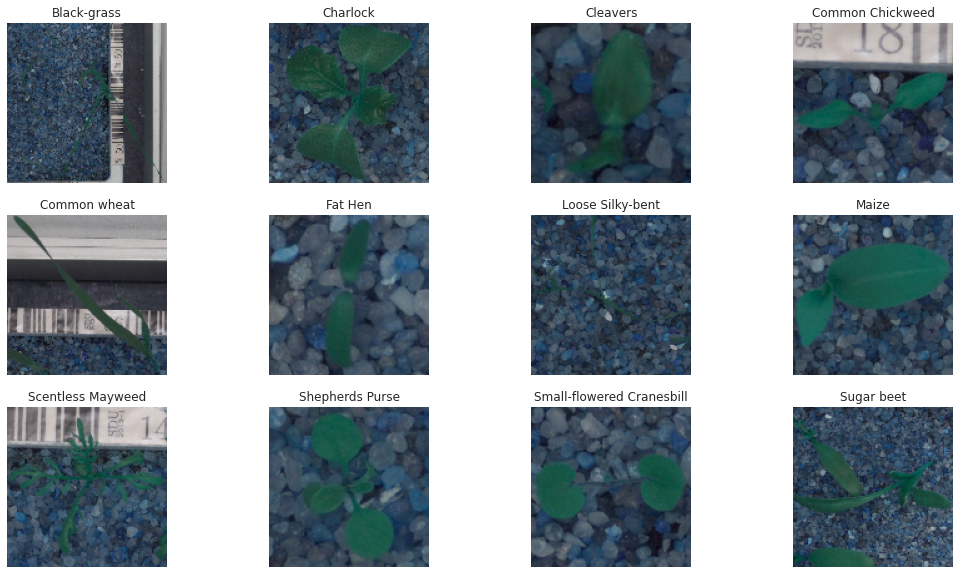

```python
#
# Visualize images in the dataset
#
def show_images(images, labels, grid_size=(3,4), width=18, height=10):
    ''' Method to visualize images

    images    - Set of images to view
    labels    - Corresponding labels for images
    grid_size - (rows, columns) for subplots
    width     - Width of the figure
    height    - height of the figure '''

    assert(len(images) == len(labels))

    # Grid to show images
    rows = grid_size[0]
    cols = grid_size[1]

    # Show image per class
    fig = plt.gcf()
    fig.set_size_inches(width, height)
    for idx, (img, lbl) in enumerate(zip(images, labels)):
        sp = plt.subplot(rows, cols, idx+1)
        sp.axis('Off')
        plt.title(lbl)
        plt.imshow(img)


# Get classes in sorted order.
# Note: The sorted order maintains compatibility with that of one-hot encoder
# used later.
labels = sorted(labels_df['Label'].unique())

# Pick first index for each category
min_label_indexes = [min(labels_df[labels_df.Label == label].index) for label in labels]

# Pick sample images based on above indexes
images_to_show = [images[idx] for idx in min_label_indexes]

# Display images along with respective labels
show_images(images_to_show, labels)
```

#### **Observations**:

- There are 4750 images each of dimension (128x128x3), height and width being 128 pixels and three color channels (RGB). The size of the images seems fine for further processing.
- There are 12 categories of plant seedlings. The given dataset is inclined towards 'Loose Silky-bent', 'Common Chickweed' and 'Scentless Mayweed' in terms of number of samples/records.
- 'Maize', 'Common wheat', and 'Shepherds Purse' have comparatively less samples. May be we should consider up sampling for these categories.
- Upon careful observation it is seen that each seedling has a background that may not be useful while classifying the category of the seedling. Background objects such as pebbles, bar-codes, fine sand can contribute to noise in data. The background should be handled in some way.
- Each plant seedling is green in color.

## Data Pre-processing

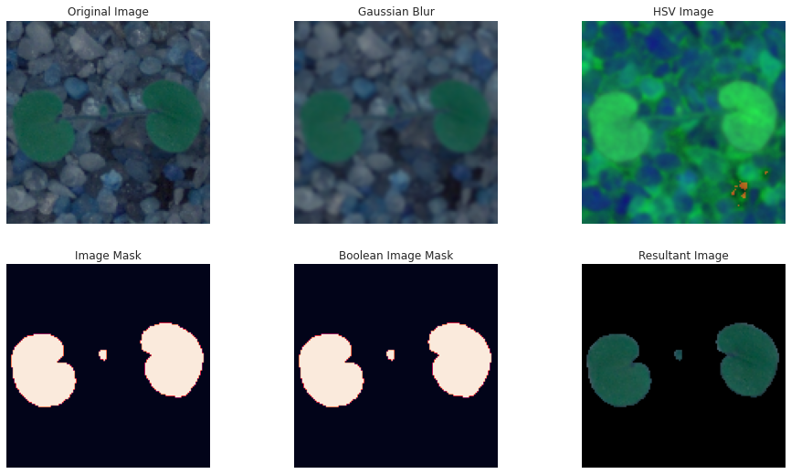

```python
#
# Let's define the algorithm for pre-processing images.
# The motivation is to hide/mask the background that may contribute to
# noise in the data.
#
def process_image(img, return_intermediates=False):
    # Apply Gaussian Blur
    gblurImg = cv2.GaussianBlur(img, (5, 5), 0)

    # Let's remove the background

    # Convert to HSV color space
    hsvImg = cv2.cvtColor(gblurImg, cv2.COLOR_BGR2HSV)
    # HSV color space lower green values
    start_hsv_green = (24, 40, 40)
    # HSV color space upper green values
    end_hsv_green = (76, 255, 255)

    # Create mask to retain green regions
    mask = cv2.inRange(hsvImg, start_hsv_green, end_hsv_green)

    # Create boolean mask
    booleanMask = (mask > 0)

    # Apply the mask to retain the seedling and remove the background
    resultImg = np.zeros_like(img, np.uint8)
    resultImg[booleanMask] = img[booleanMask]

    # Return intermediate results if requested
    if return_intermediates:
        return [img, gblurImg, hsvImg, mask, booleanMask, resultImg]

    # Return final processed image
    return resultImg


# Let's look at the effects of pre-processing on a sample image
sample_img = images[0]

# Get all image transformations
transformations = process_image(sample_img, return_intermediates=True)

# Titles for transformations
tranform_titles = ['Original Image', 'Gaussian Blur', 'HSV Image', 'Image Mask',
                   'Boolean Image Mask', 'Resultant Image']


# Show transformations on a sample image
show_images(transformations, tranform_titles, grid_size=(2,3), width=16, height=9)
```

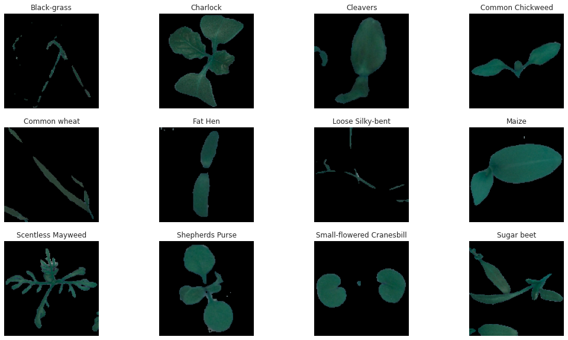

```python
# Let's pre-process all given images
processed_images = []
for img in images:
    result = process_image(img)
    processed_images.append(result)

# Normalize image data
processed_images = np.asarray(processed_images, dtype=np.float32)
processed_images /= 255.0

# Get sample pre-processed imges per category
images_to_show = [processed_images[i] for i in min_label_indexes]

# View pre-processed images on different categories of seedlings
show_images(images_to_show, labels)
```

#### **Observations**:

- In the data pre-processing step we are able to mask the background and focus on the actual seedling
- This will help our model to not be impacted by the noise and extract features related to actual seedling.

## Data Preparation: Making data compatible

```python
# One hot encode labels
encoder = OneHotEncoder(handle_unknown='ignore')
labels_ohe = encoder.fit_transform(labels_df).toarray()

# Print one hot encoding details
print("Shape of One Hot Encoded Labels: ", labels_ohe.shape)
print()
print("{0:30}\t{1}".format('Label', 'One Hot Encoded Vector'))
print("{0:25}\t{1}".format('-----------', '----------------------------------'))
for category, idx in zip(encoder.categories_[0], min_label_indexes):
    print("{0:25}\t{1}".format(category, labels_ohe[idx]))
```

```
Shape of One Hot Encoded Labels:  (4750, 12)

Label                         	One Hot Encoded Vector
-----------              	----------------------------------
Black-grass              	[1. 0. 0. 0. 0. 0. 0. 0. 0. 0. 0. 0.]
Charlock                 	[0. 1. 0. 0. 0. 0. 0. 0. 0. 0. 0. 0.]
Cleavers                 	[0. 0. 1. 0. 0. 0. 0. 0. 0. 0. 0. 0.]
Common Chickweed         	[0. 0. 0. 1. 0. 0. 0. 0. 0. 0. 0. 0.]
Common wheat             	[0. 0. 0. 0. 1. 0. 0. 0. 0. 0. 0. 0.]
Fat Hen                  	[0. 0. 0. 0. 0. 1. 0. 0. 0. 0. 0. 0.]
Loose Silky-bent         	[0. 0. 0. 0. 0. 0. 1. 0. 0. 0. 0. 0.]
Maize                    	[0. 0. 0. 0. 0. 0. 0. 1. 0. 0. 0. 0.]
Scentless Mayweed        	[0. 0. 0. 0. 0. 0. 0. 0. 1. 0. 0. 0.]
Shepherds Purse          	[0. 0. 0. 0. 0. 0. 0. 0. 0. 1. 0. 0.]
Small-flowered Cranesbill	[0. 0. 0. 0. 0. 0. 0. 0. 0. 0. 1. 0.]
Sugar beet               	[0. 0. 0. 0. 0. 0. 0. 0. 0. 0. 0. 1.]
```

```python
# Create copies for data and labels
X = copy.deepcopy(processed_images)
Y = copy.deepcopy(labels_ohe)
print('X shape: ', X.shape)
print('Y shape:', Y.shape)
print()

# Get train and test split with 30% split for test data
x_train, x_test, y_train, y_test = train_test_split(X, Y, test_size=0.30,
                                                random_state=SEED, stratify=Y)

# Further split test data into test and validation data with 50% split.
x_valid, x_test, y_valid, y_test = train_test_split(x_test, y_test,
                                    test_size=0.50, random_state=SEED,
                                    stratify=y_test)

# Print distributions
print('Train data:')
print('X Train Shape:', x_train.shape)
print('Y Train Shape:', y_train.shape)
print()
print('Validation Data:')
print('X Valid Shape:', x_valid.shape)
print('Y Valid Shape:', y_valid.shape)
print()
print('Test Data:')
print('X Test Shape:', x_test.shape)
print('Y Test Shape:', y_test.shape)
print()
```

```
X shape:  (4750, 128, 128, 3)
Y shape: (4750, 12)

Train data:
X Train Shape: (3325, 128, 128, 3)
Y Train Shape: (3325, 12)

Validation Data:
X Valid Shape: (712, 128, 128, 3)
Y Valid Shape: (712, 12)

Test Data:
X Test Shape: (713, 128, 128, 3)
Y Test Shape: (713, 12)
```

```
	Sample Train Image                      Sample Test Image                  Sample Validation Image
```

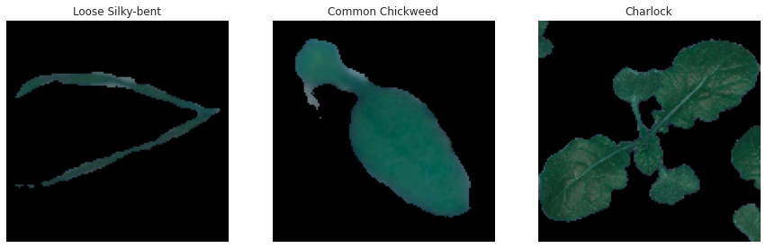

```python
# Show sample images from train, validation and test datasets with labels
images_to_show = [x_train[0], x_test[0], x_valid[0]]
labels_to_show_ohe = [y_train[0], y_test[0], y_valid[0]]
labels_to_show = [labels[np.argmax(label_ohe)] for label_ohe in labels_to_show_ohe]

print('\t{0:40}{1:35}{2}'.format('Sample Train Image', 'Sample Test Image',
                                 'Sample Validation Image'))

# View sample images from train, test and validation data
show_images(images_to_show, labels_to_show, grid_size=(1, 3), width=15, height=7)
```

#### *Observations*:

- In this section, we prepared the input data and labels to be ready for the model, which we will be building in the following section.
- The labels have been converted to one hot encoded vectors.
- The dataset has been split into train, validation and test sets.
- The original shape of data (128, 128, 3) is compatible for training the model.

## Building CNN model

```python
# Start with sequential model.
model = Sequential()

# Define Feature Extractor

# First convolution layer with 32 filters and ReLU activation followed by MaxPooling
# This layer interfaces to the input of shape (128, 128, 3)
model.add(Conv2D(32, 3, strides=1, input_shape=(128, 128, 3), activation='relu'))
model.add(MaxPooling2D((2, 2)))

# Second convolution layer with 64 filters and ReLU activation followed by MaxPooling
model.add(Conv2D(64, 3, strides=1, activation='relu'))
model.add(MaxPooling2D((2, 2)))

# Third convolution layer with 128 filters and ReLU activation followed by MaxPooling
model.add(Conv2D(128, 3, strides=1, activation='relu'))
model.add(MaxPooling2D((2, 2)))

# Fourth convolution layer with 256 filters and ReLU activation followed by MaxPooling
model.add(Conv2D(256, 3, strides=1, activation='relu'))
model.add(MaxPooling2D((2, 2)))

# Classifier

# Flatten inputs with batch normalization
model.add(Flatten())
model.add(BatchNormalization())

# Add first fully connected layer with 64 neurons followed by batch normalization and ELU activation
model.add(Dense(64, kernel_initializer='he_normal', use_bias=False))
model.add(BatchNormalization())
model.add(Activation('elu'))

# Add second fully connected layer with 32 neurons followed by batch normalization and ELU activation
model.add(Dense(32, kernel_initializer='he_normal', use_bias=False))
model.add(BatchNormalization())
model.add(Activation('elu'))

# Add output layer for multi-class classification with softmax activation function
model.add(Dense(12, activation='softmax'))

# Create optimizer instance with slightly lower learning rate, as we have batch normalization to converge faster
opt = optimizers.Adam(lr=0.001)

# Configure the model with categorical cross entropy loss, the optimizer,
# and accuracy as the metrics
model.compile(loss='categorical_crossentropy', optimizer=opt, metrics=['accuracy'])

# Print model summary
model.summary()
```

```
Model: "sequential"
_________________________________________________________________
Layer (type)                 Output Shape              Param #
=================================================================
conv2d (Conv2D)              (None, 126, 126, 32)      896
_________________________________________________________________
max_pooling2d (MaxPooling2D) (None, 63, 63, 32)        0
_________________________________________________________________
conv2d_1 (Conv2D)            (None, 61, 61, 64)        18496
_________________________________________________________________
max_pooling2d_1 (MaxPooling2 (None, 30, 30, 64)        0
_________________________________________________________________
conv2d_2 (Conv2D)            (None, 28, 28, 128)       73856
_________________________________________________________________
max_pooling2d_2 (MaxPooling2 (None, 14, 14, 128)       0
_________________________________________________________________
conv2d_3 (Conv2D)            (None, 12, 12, 256)       295168
_________________________________________________________________
max_pooling2d_3 (MaxPooling2 (None, 6, 6, 256)         0
_________________________________________________________________
flatten (Flatten)            (None, 9216)              0
_________________________________________________________________
batch_normalization (BatchNo (None, 9216)              36864
_________________________________________________________________
dense (Dense)                (None, 64)                589824
_________________________________________________________________
batch_normalization_1 (Batch (None, 64)                256
_________________________________________________________________
activation (Activation)      (None, 64)                0
_________________________________________________________________
dense_1 (Dense)              (None, 32)                2048
_________________________________________________________________
batch_normalization_2 (Batch (None, 32)                128
_________________________________________________________________
activation_1 (Activation)    (None, 32)                0
_________________________________________________________________
dense_2 (Dense)              (None, 12)                396
=================================================================
Total params: 1,017,932
Trainable params: 999,308
Non-trainable params: 18,624
_________________________________________________________________
```

#### *Observations*:

- The thought process here is to build a good feature extractor and a good classifier for classifying 12 categories of plant seedlings.
- Batch Normalization, Max Pooling, different activation functions, different learning rates have been considered while building the model.

## Training and Evaluating the Model

```python
#
# Based on the observations while training, 90% accuracy on train and validation
# data is fairly good. After that the model might overfit.
#
# Let's define a callback for early stopping based on both train and validation
# accuracies
#
class TerminateOverBaseline(Callback):
    '''Callback that terminates training when given prameters reach specified
        baseline'''

    def __init__(self, monitor=[], baselines=[]):
        super(TerminateOverBaseline, self).__init__()
        self.monitor = monitor
        self.baselines = baselines

    def on_epoch_end(self, epoch, logs=None):
        logs = logs or {}
        results = []

        # Collect all required results from this epoch
        for mon in self.monitor:
            res = logs.get(mon)
            if res is None: return
            results.append(res)

        # Check if all of the results are above their respective specified baselines
        assert len(results) == len(self.baselines)
        for r,b in zip(results, self.baselines):
            if r < b: return

        # Stop training
        self.model.stop_training = True
        print('\nEpoch {0} satisfied all baselines, terminating training.\n'.
              format(epoch))

# Create instance of the callback for train and validation accuracy of 91% baselines
callback = TerminateOverBaseline(monitor=['accuracy','val_accuracy'],
                                 baselines=[0.90, 0.90])

# Define data generator for data augmentation and scaling
# Reference: https://www.tensorflow.org/api_docs/python/tf/keras/preprocessing/image/ImageDataGenerator
datagenerator = ImageDataGenerator(
                    rotation_range = 180,
                    zoom_range = 0.15,
                    width_shift_range = 0.10,
                    height_shift_range = 0.10,
                    horizontal_flip = True,
                    vertical_flip = True)

# Compute quantities required for featurewise normalization
datagenerator.fit(x_train)

# Create data iterator for training data
data_itr = datagenerator.flow(x_train, y_train, batch_size=64)

# Train the model
start = time.time()
hist = model.fit(data_itr, epochs=70, validation_data=(x_valid, y_valid),
                 callbacks=[callback], verbose=True)
end = time.time()

# Print training duration
print('Training took: {0} seconds'.format(round(end-start, 2)))
```

```
Epoch 25 satisfied all baselines, terminating training.

Training took: 334.22 seconds
```

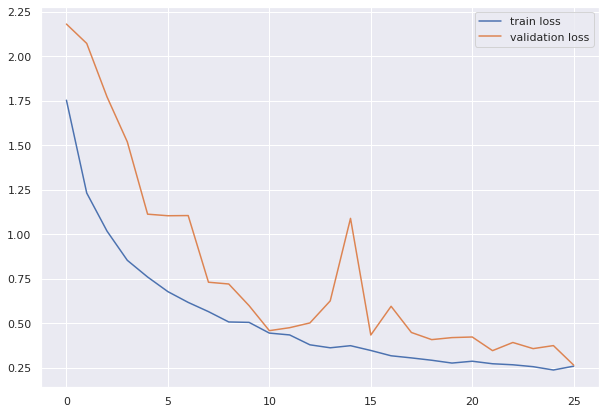

```python
# Let's plot the train and validation loss to see if there's is overfitting
train_hist = pd.DataFrame(hist.history)
plt.figure(figsize=(10, 7))
plt.plot(train_hist['loss'])
plt.plot(train_hist['val_loss'])
plt.legend(("train loss" , "validation loss"), loc=0)
```

```python
# Get train accuracy
results = model.evaluate(x_train, y_train, batch_size=64, verbose=False)
print('Train accuracy: ', round(results[1] * 100,3))

# Get test accuracy
results = model.evaluate(x_test, y_test, batch_size=64, verbose=False)
print('Test accuracy: ', round(results[1] * 100, 3))
```

```
Train accuracy:  93.083
Test accuracy:  91.585
```

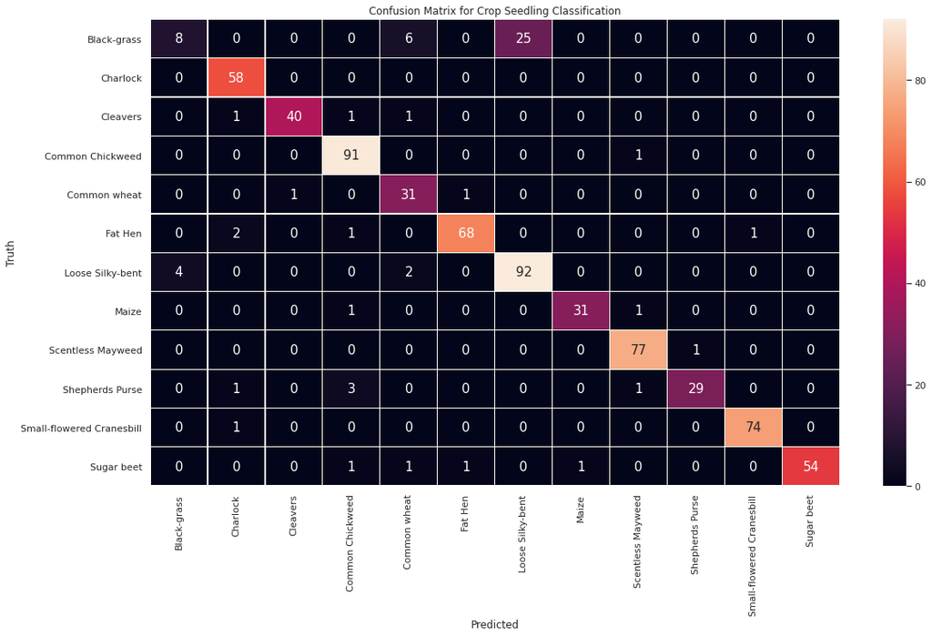

```python
# Get model predictions
y_pred = model.predict(x_test)

y_test_labels = []
y_pred_labels = []
for t, p in zip(y_test, y_pred):
    y_test_labels.append(np.argmax(t))
    y_pred_labels.append(np.argmax(p))

# Compute the confusion matrix
cm = confusion_matrix(y_test_labels, y_pred_labels)
cm = np.asarray(cm)

# Plot the matrix
plt.figure(figsize=(18,10))
cm_df = pd.DataFrame(cm, index=labels, columns=labels)
sns.heatmap(cm_df, annot=True, linewidths=0.3, annot_kws={"fontsize":15}, fmt='g')
plt.title('Confusion Matrix for Crop Seedling Classification')
plt.xlabel("Predicted")
plt.ylabel("Truth")
plt.show()
```

```python
# Let's look at the precision and recall for the model.
recall, precision = Recall(), Precision()
recall.update_state(y_test, y_pred)
precision.update_state(y_test, y_pred)

print('Recall Score:', round(recall.result().numpy(), 3))
print('Precision Score: ', round(precision.result().numpy(), 3))
```

```
Recall Score: 0.905
Precision Score:  0.919
```

#### *Observations*:

- Good number of convolution layers with more filters were found helpful.
- Max pooling layers helped amplify important features and eliminate subtle noise.
- Batch normalization in the feature extractor did not help much and ended up in model over-fitting. However, using batch normalization in the classifier helped. Note: Batch normalization had to be added before the activation layer to be effective.
- In addition, the kernel initialization used was 'he_normal' and biased were disabled for classifier.
- Lower learning rate was found useful.
- The model performed considerably well on the training and validation data. It also demonstrated good classification performance in terms of accuracy, precision and recall scores on the test data.
- We see a saw-tooth like graph for the validation loss. This could be further smoothen trying different combinations of learning rate and batch size.
- The confusion matrix showed that the model did fairly well. We see maximum values along the diagonal and minimum values elsewhere indicating significant number of true positives and true negatives.
- The model is not very confident about 'Loose Silky-bent' and 'Black-grass'. This could be because of lack of training samples for 'Black-grass'.

## Visualize Predictions

```
				 Original Labels
```

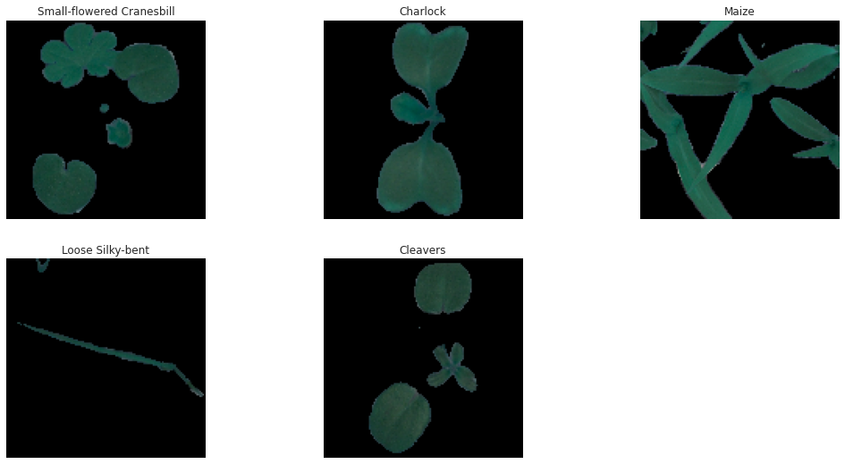

```python
# Let's visualize predictions for:
# x_test[2], x_test[3], x_test[33], x_test[36], x_test[59]
test_indexes = [2, 3, 33, 36, 59]
# Test images
test_images = [x_test[idx] for idx in test_indexes]
# Test labels (text)
test_labels = [labels[np.argmax(y_test[idx])] for idx in test_indexes]

print("\t\t\t\t Original Labels\n")
# Show original test iamges and real labels
show_images(test_images, test_labels, grid_size=(2, 3), width=18, height=9)
```

```
				 Inferred Labels
```

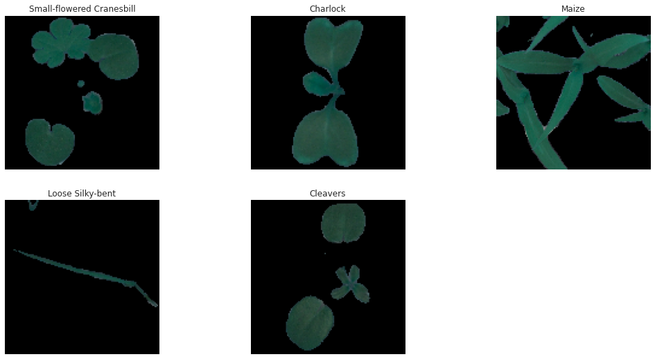

```python
# Let's predict using the trained model on the test images selected above
predicted_labels = []
for idx in test_indexes:
    img = np.asarray(x_test[idx])
    img = (np.expand_dims(img, 0))
    prediction = model.predict(img)
    predicted_labels.append(labels[np.argmax(prediction)])

# Show images with predicted labels
print("\t\t\t\t Inferred Labels\n")
show_images(test_images, predicted_labels, grid_size=(2, 3), width=18, height=9)
```

#### *Observations*:

1. The inferred labels match accurately to the original labels, indicating impressive classification performance by the trained model.
2. We were able to achieve significant performance for classifying plant seedlings, which to me looked difficult to achieve for human eyes.